# Uitbreiding visiegebied Duivenbos Gevolgen voor buurtbewoners

Auteur

Bernadette Michiels  
Karel De Tremerie

Publicatiedatum

17 augustus 2024

# De betrokken partijen: wie is wie?

## De Overheid

### Migratie van beslissingsmacht

In principe worden politieke beslissingen genomen door regering en parlement. Sinds enkele decennia zien we dat de Brusselse wetstraat niet langer de plaats is waar beslissingen genomen worden. De politieke beslissingsmacht migreert. (Huyse, 2014, pp. 18–20)

Huyse, L. (2014). *De democratie voorbij*. Van Halewyck.

De **horizontale migratie** begon kort na de Tweede Wereldoorlog. Grote stukken sociaal en economisch beleid werden in onderaanneming gegeven van de sociale partners, vakbonden en patronaat. Onderwijs, cultuur, ziekenzorg en maatschappelijk werk, werden toevertrouwd aan christelijke, socialistische en liberale organisaties (verzuiling).

In beide gevallen gaan regering en parlement slechts als contractanten om met die andere producenten van politieke beslissingen. Zij onderhandelen met hen en laten hen, binnen een door de overheid afgebakende gedoogzone, een koers uitstippelen.

Ook op bestuurlijk vlak heeft zich een gelijkaardige wijziging voorgedaan. Men spreekt over ‘*horizontaal bestuur*’. Daarbij ontstaat een formeel partnerschap tussen regering en parlement enerzijds en de particuliere sector anderzijds. In Vlaanderen kennen we dergelijke vormen van gemengde bestuur via **agentschappen** als IVA’s[^1] en EVA’s.[^2]

<sup>1</sup> IVA: Intern verzelfstandigde agentschappen

<sup>2</sup> EVA: Extern publiekrechtelijke of privaatrechtelijk vormgegeven agentschappen

Met **verticale migratie** bedoelen we het verschuiven van bevoegdheden naar boven (Europa Instellingen, IMF, Internationaal Strafhof, …) en naar beneden (regio’s, provincies, steden en gemeenten).

Door de staatshervormingen werden verschillende bevoegdheden overgeheveld van de unitaire staat naar de **gewesten**. De gewesten werden bevoegd voor tal van materies die de burger rechtstreeks raken zoals

- ruimtelijke ordening (ruimtelijke plannen, bouwvergunningen, … )
- leefmilieu (o.a. bescherming van het leefmilieu)
- landinrichting en natuurbehoud

### Beleidsdomeinen van de Vlaamse overheid

Deze bevoegdheden van de Vlaamse overheid worden gerealiseerd door verschillende overheidsdiensten, die gegroepeerd worden in **beleidsdomeinen**.

Een beleidsdomein bestaat uit een **departement** en een of meer **agentschappen** (horizontaal bestuur).

- Het *departement* zorgt voor de beleids*voorbereiding* en de beleidsondersteuning. Het werkt onder het directe gezag en onder de verantwoordelijkheid van de minister.
- Een *agentschap* is voornamelijk verantwoordelijk voor beleids*uitvoerende* taken en heeft een grotere mate van autonomie. Daarom spreekt men ook over ‘verzelfstandigde’ agentschappen.

Deze structuur werd in 2006 ingevoerd bij de grootschalige reorganisatie onder de noemer ‘Beter Bestuurlijk Beleid’ (BBB). In de praktijk werken departementen en agentschappen nauw samen bij zowel beleidsvoorbereiding als beleidsuitvoering.

### Beleidsdomein Omgeving

Het Vlaamse Gewest is bevoegd voor het omgevingsbeleid in Vlaanderen. Het is de Vlaamse Regering die de eindbeslissingen neemt, op initiatief van de Vlaamse minister voor Omgeving. Voor het beleidsvoorbereidend en beleidsuitvoerend werk kan de minister van Omgeving rekenen op een aantal organisaties:

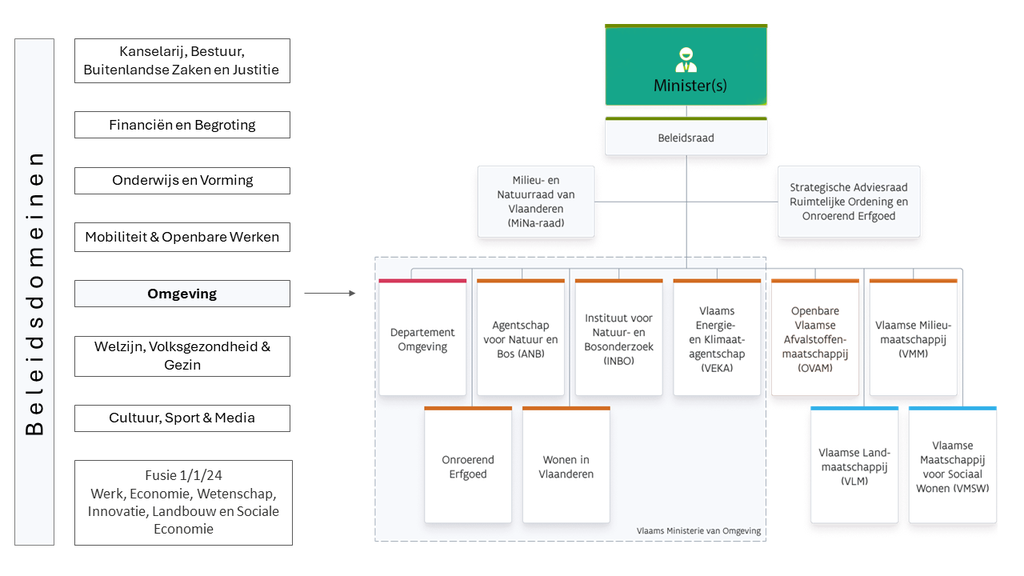

Beleidsdomein Omgeving - organogram (click to enlarge)

#### Agentschap Natuur en Bos (ANB)

Het Agentschap voor Natuur en Bos, beschermt en ontwikkelt ruim 90.000 hectare aan natuurgebieden, bossen en parken in Vlaanderen. Ze ondersteunen waardevolle natuurprojecten met financiële middelen én vakmanschap.

ANB streeft naar:

- Instandhouding van de huidige aanwezige natuur in Vlaanderen en deze natuur verder ontwikkelen en beschermen
- Herstellen van natuur die in het verleden verloren is gegaan
- Ontwikkelen van nieuwe natuur en parkgebieden waarbij gestreefd wordt naar betere natuur door het beheren van de natuur op een duurzame wijze.

Het verhogen van de biodiversiteit in Vlaanderen behoort tot de strategische doelstelling van ANB.

#### MiNa-Raad (Milieu- en Natuurraad van Vlaanderen)

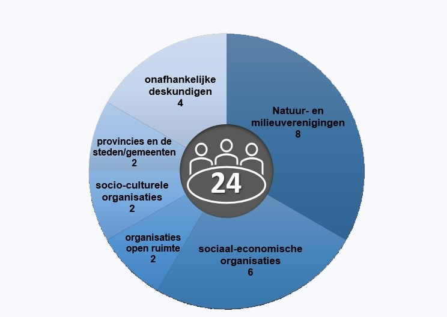

Samenstelling MiNa-raad (click to enlarge)

De MiNa-raad is een adviesorgaan van de Vlaamse Regering met een algemene bevoegdheid inzake studie, aanbeveling en advies voor alles wat verband houdt met milieu en natuur.

Zoals duidelijk bepaald in het decreet van 5 april 1995 houdende algemene bepalingen inzake milieubeleid, hebben milieu en milieubeleid een ruime betekenis. Hierdoor houdt de Raad zich ook bezig met thema’s als duurzame ontwikkeling, ruimtelijke ordening, energie, mobiliteit, landbouw en natuurlijke hulpbronnen.

De adviezen die de Raad verstrekt zijn niet bindend. De besluitvormers zijn vrij om de aangereikte argumenten en opmerkingen al dan niet in hun beleid te integreren.

## Boerenbond

### De landbouwcrisis van 1880

Tussen 1845 en 1847 vernielde een tot dan onbekende schimmelziekte (Phytophtora infestans) de aardappeloogst in grote delen van Noord- en West-Europa (1845, Vlaanderen, -87%). Daar bovenop zijn er door de zeer slechte weersomstandigheden in 1846 ook aanzienlijke minderopbrengsten in de rogge en tarwe. Door deze voedselcrisis ontstaat er hongersnood. Naar schatting 44.000 mensen kwamen tussen 1845 en 1847 om door honger en ziekte in België, waarvan zo’n 30.000 in de provincies Oost- en West-Vlaanderen. De daaropvolgende jaren is er een stijgende trend in de prijzen van agrarische producten. En dit zal leiden tot een nieuwe crisis.

Ondertussen werden in Noord-Amerika grote oppervlakten landbouwgebied ontgonnen.

**De Homestead Act van 1862 en de eerste agrarische revolutie in de VS (Morison et al., 1977, pp. 424–435)**

Door de Homestead Act van 1862 konden ‘settlers’ quasi gratis 160 ‘acres’ (64 hectare) grond verwerven in het Westen (nu: midden-Amerika). Als voorwaarde werd gesteld dat men minstens vijf jaar op de grond moest blijven wonen. Veel settlers verbraken echter het contract en verlieten de gronden vooraleer de vijf jaren verstreken waren. En daar waren diverse redenen voor.

- Klimatologisch: zonder irrigatie was het klimaat in de Midwest niet geschikt voor landbouw.
- In tegenstelling met Oost Amerika bestond de Midwest uit ‘prairies’ en niet uit loofbossen. Hout was schaars. Het was dan ook onmogelijk het vee binnen omheiningen te houden. Daardoor was er ook geen mest beschikbaar.
- Doordat kunstmest nog niet bestond moest men noodgedwongen aan extensieve landbouw doen. Na één seizoen werd doorgeschoven naar een volgende perceel. Het vorige perceel bleef onbedekt liggen en leed zwaar onder erosie. De oorspronkelijk ‘160 acres’ bleek al gauw onvoldoende.
- Het voornaamste landbouwwerktuig, de ploeg, was gemaakt van hout en/of gietijzer. Ze had een ruw blad waardoor de prairiegrond aan de ploeg bleef kleven. Ploegen ging traag en moeizaam.
- Mechanisatie was nog niet doorgebroken. Er waren arbeidskrachten tekort voor het vele werk.
- Door gebrek aan infrastuctuur kon de oogst niet vervoerd worden.
- Er was veel fraude door niet-landbouwers die gronden probeerden te verwerven. De spoorwegmagnaten speelden een belangrijke rol. (voor een uitgebreide beschrijving van de problematiek Morison p.426)
- De inheemse bevolking was niet steeds opgezet met de komst van de settlers. Dit leidde vaak tot bloedige conflicten met Sioux, Apaches, Arapaho en Cheyennes en brachten veel leed en verlies van mensenlevens met zich mee aan beide zijden. Ze vormen een tragisch onderdeel van de Amerikaanse geschiedenis van westwaartse expansie en de interactie tussen settlers en inheemse bevolkingsgroepen.

De Amerikaanse overheid werd zich snel bewust van de problemen en nam verschillende maatregelen. De ‘160 acres’ werd uitgebreid en er werd spoed gezet achter de aanleg van een spoorlijn die Oost en West zou verbinden.

Na 1870 geraakten een aantal van deze problemen opgelost.

- In 1837 ontwikkelt John Deere een ploeg, voorzien van stalen ploegmessen, waardoor deze veel sterker en duurzamer was dan de traditionele houten ploegen. Het gebruik van staal maakte de ploeg ook scherper waardoor hij gemakkelijker door de grond kon snijden en een gladdere ploegsnee kon maken waardoor de aarde niet aan de ploeg bleef plakken. De uitvinding van de stalen ploeg wordt beschouwd als een van de belangrijkste innovaties in de landbouwgeschiedenis, omdat het de landbouwproductiviteit aanzienlijk verhoogde en een revolutie teweegbracht in de landbouwpraktijken. Pas in de tweede helft van de negentiende eeuw schakelt men over op industriele productie van de ploegen.
- In 1854 wordt de eerste zelf-regelende windmolen gepatenteerd (self-regulating water pump windmills). Deze windmolen, meer nog dan de spoorwegen, was cruciaal voor de kolonisatie van het Midden-Westen. Windmolens maakten het mogelijk voor veehouders en boeren om te wonen en te werken op land waar geen betrouwbare natuurlijke watervoorziening was. En toen de spoorlijnen begonnen uit te breiden richting de Stille Oceaan, leverden windmolens het water voor de locomotieven en degenen die ze moesten bedienen.
- In 1869 werd de Union Pacific Railroad in gebruik genomen. Deze spoorweg met Californië als bestemming was de eerste transcontinentale spoorweg.
- Het tekort aan werkkrachten op de nieuwe landbouwbedrijven (cfr. The Civil War: 1861-1865) stimuleerde de ontwikkeling van nieuwe landbouwwerktuigen. In de tweede helft van de negentiende eeuw schakelt men over op industriele productie van landbouwwerktuigen en machines. Mechanisatie deed zijn ingang met dors-, maai-, pik- en zaaimachines. Maar alle machines werden nog getrokken door paarden. Na 1880 komen stoommachines geleidelijk aan in gebruik.
- In 1873 wordt prikkeldraad (barbed wire) uitgevonden wat een intensivering van de veeteelt toeliet.

Morison, S., Commager, H., & Leuchtenburg, W. (1977). *A Concise History of the American Republic* (p. 761). Oxford Univeristy Press.

Aangetrokken door de hoge Europese prijzen ging het Amerikaanse graan de markt hier overspoelen (de ‘agrarische invasie’ van 1880-1895): de prijzen stortten in en een grote crisis brak uit onder de landbouwbevolking. In de jaren die volgen grijpt een rurale exodus plaats. Niet alleen de landbouwcrisis maar ook de explosieve uitbreiding van de industrie, die een sterke aantrekking uitoefent door hoge lonen, zorgen daarvoor.

### Boeren gekneld in het systeem

Boeren zaten vaak gekneld in het systeem door hun afhankelijkheid van de grondeigenaar en oneerlijke handelspraktijken. (Craeybeckx, 1973, pp. 208–211)

Craeybeckx, J. (1973). De agrarische depressie van het einde der XIXe eeuw en de politieke strijd om de boeren (1ste deel). *Belgisch Tijdschrift voor Nieuwste Geschiedenis (BTNG)*, *4(01-02)*, 191–230. https://www.journalbelgianhistory.be/en/system/files/article_pdf/BTNG-RBHC,%2004,%201973,%201-2,%20pp%20191-230.pdf

*“De klachten over het bedrog op de kwaliteit door handelaars in kunstmest, veevoeder, zaaigoed, enz. waren niet uit de lucht. De misbruiken op dat gebied waren nog ondraaglijker wanneer de (grond)eigenaar tegelijk een graanhandelaar was en er zijn pachters toe verplichtte de zaden bij hem te kopen tegen sterk overdreven prijzen. Van hun invloed maakten dezelfde eigenaars soms gebruik om een agentschap voor verzekeringen tegen brand, een handel in scheikundige meststoffen, ja zelfs een kruidenierszaak op te zetten. De monografie van Thuysbaert over het Land van Waas meldt eveneens dat sommige brouwers er hun pachters toe noopten jaarlijks een aantal tonnen bier af te nemen, zodat ze een herberg moesten openen.”*

Van mechanisatie, zoals in Amerika, was weinig te merken door kapitaalgebrek.

*“De boeren verdienden echter te weinig om te investeren in technische vernieuwing, wat de vooruitgang van de produktiviteït remde. De kleine en de gemiddelde boeren hielden er geen boekhouding op na, wat de rationalisatie van de bedrijven zeker niet bevorderde. Over het algemeen werden er weinig landbouwmachines gebruikt, zeker niet op kleine uitbatingen en in de armste gewesten. In sommige dorpen waren er een paar dorsmachines met paarden of stoom. Men sprak de vrees uit dat ze werkloosheid zouden veroorzaken en de vlucht van de landbouwarbeiders naar de industrie bespoedigen.”*

Zowel in perioden van sterk toegenomen vraag (zoals tijdens voedseltekorten in de eerste helft van de negentiende eeuw) als van voedseloverschot (wat gepaard ging met scherpe prijsdalingen, zoals tijdens de laatste decennia van de negentiende eeuw), werden beleidsmaatregelen genomen om het aanbod van en de vraag naar voedsel in het ‘gewenste’ evenwicht te brengen. In 1884, als reactie op de crisis, werd het Ministerie van Landbouw opgericht.

Landbouwverenigingen waren er op dat moment nog maar weinig. Wat wel al bestond, waren onderlinge bijstandskassen om verlies van vee te compenseren, en coöperaties voor gezamenlijke aankoop van kunstmest. Pas na 1886, en vooral in de jaren negentig, zouden landbouwersverenigingen het licht zien.

### Landbouwgilden

Tegen het einde van de negentiende eeuw beginnen boeren zich te organiseren in landbouwgilden. Deze gilden waren lokaal georganiseerd met als doel om samen sterker te staan tegenover de economische en sociale uitdagingen. Ze boden een platform voor kennisuitwisseling, gezamenlijke aankopen, en collectieve verkoop van producten, wat de individuele positie van boeren verbeterde. Daarnaast fungeerden de gilden vaak als sociaal vangnet en promootten ze modernisering en innovatie in de landbouwpraktijken, wat cruciaal was voor de overleving en vooruitgang van de sector.

### Oprichting van de Boerenbond

Voor een uitgebreide bespreking zie (Van Molle, 1990, pp. 21–45)

Van Molle, L. (1990). *Ieder Voor Allen: De Belgische Boerenbond, 1890-1990*. Universitaire Pers Leuven en Belgische Boerenbond.

Joris Helleputte, een invloedrijke katholieke ingenieur en politicus, en pastoor Mellaerts richtten de Boerenbond op in 1890 om de belangen van de Vlaamse boeren te verdedigen en te versterken. Hun initiatief was diep geworteld in het katholicisme, wat de ideologische basis vormde voor de Boerenbond. Ze zagen de organisatie niet alleen als een economisch instrument, maar ook als een morele en religieuze gids voor de landbouwgemeenschap. De Boerenbond moest de Vlaamse boeren ondersteunen en beschermen door hen te organiseren binnen een katholiek, corporatistisch en coöperatief kader.

#### Katholicisme

In het laat-19e-eeuwse België was de katholieke kerk een invloedrijke macht die zich inzette voor de bescherming van de boeren en arbeiders tegen de negatieve effecten van de industriële revolutie en de opkomst van het socialisme. De Boerenbond werd gezien als een middel om de katholieke waarden en normen te handhaven binnen de plattelandsgemeenschappen, door hen te organiseren en hun positie te versterken tegen de ontkerkelijking en verstedelijking.

#### Standenorganisatie

De Boerenbond functioneerde als een standenorganisatie, wat betekende dat het de belangen van een specifieke sociale klasse, namelijk de boeren, vertegenwoordigde. Dit concept was gebaseerd op het idee dat de samenleving verdeeld was in verschillende standen of groepen, elk met hun eigen rechten en plichten.[^3] De Boerenbond probeerde de landbouwstand te versterken door hen te verenigen en hen een stem te geven in het politieke en economische debat.

<sup>3</sup> Een standenorganisatie is een structuur waarin de samenleving wordt verdeeld in verschillende groepen of standen, zoals boeren, arbeiders, geestelijken, en adel, waarbij elke stand een specifieke rol en verantwoordelijkheid heeft. In een standenorganisatie werkt men vanuit het idee dat deze verschillende sociale groepen moeten worden georganiseerd en vertegenwoordigd op een manier die hun unieke belangen beschermt en hun positie binnen de samenleving versterkt. Het is sterk verbonden met de middeleeuwse samenleving, waar elke stand zijn eigen rechten en plichten had.

#### Corporatisme

De oprichting van de Boerenbond was ook een uiting van corporatisme, een ideologie die streeft naar samenwerking tussen verschillende sectoren van de samenleving — zoals arbeid, kapitaal en de overheid — om het algemeen welzijn te bevorderen. Corporatisme verwerpt de klassenstrijd en bevordert in plaats daarvan samenwerking en harmonie tussen de verschillende sociale groepen.[^4] De Boerenbond werd opgericht als een corporatieve organisatie die de belangen van de boerenstand moest verdedigen binnen het bredere sociale en economische kader van België.

<sup>4</sup> Corporatisme probeert sociale conflicten te vermijden door alle groepen te integreren in een systeem van overleg en samenwerking. Het idee is dat door samenwerking tussen verschillende sectoren van de samenleving, het algemeen belang beter wordt gediend dan door individuele of klassenstrijd. Corporatisme werd in de 19e en 20e eeuw gepromoot als een alternatief voor zowel kapitalisme als socialisme, met als doel de economische stabiliteit en sociale harmonie te bevorderen door een georganiseerde samenwerking tussen verschillende maatschappelijke sectoren.

#### Coöperatieve

Een belangrijk aspect van de Boerenbond was de ontwikkeling van coöperatieve structuren. Dit hield in dat boeren zich verenigden in coöperaties om gezamenlijk inkopen te doen, hun producten te verkopen en krediet te verkrijgen. Deze coöperatieve aanpak gaf de boeren meer economische macht en verminderde hun afhankelijkheid van tussenpersonen en grote handelaren. Het coöperatieve model werd gezien als een praktisch middel om de economische positie van de boeren te verbeteren en hen in staat te stellen te concurreren in een snel veranderende markt.

## Natuurpunt

Natuurpunt is een organisatie die zich inzet voor de bescherming en bevordering van natuur en biodiversiteit. De oprichting van Natuurpunt was het resultaat van een fusie tussen twee eerdere organisaties, de “Vereniging voor Natuur- en Landschapsbescherming” (VNL) en de “Vlaamse Natuurvereniging” (VNV). Deze fusie stelde de nieuwe organisatie in staat om een bredere reikwijdte en grotere impact te hebben op het gebied van natuurbehoud in Vlaanderen.

### Oprichting

In 1933 werd in Antwerpen **De Wielewaal** opgericht, voorloper van Natuurpunt. De organisatie bestudeerde en beschermde in het wild levende vogels. Een tweede afdeling in Turnhout was het startsein voor een bloeiende vereniging met een netwerk in heel Vlaanderen. De afdelingen organiseerden uitstappen, informatieavonden, cursussen, diamontages en reizen en vormden zo de drijvende kracht van de vereniging. Het aantal afdelingen liep ondertussen op tot een zestigtal.

Eind jaren veertig groeide het besef dat interessante landschappen en biotopen daadwerkelijk beschermd moesten worden. Daarom spoorde De Wielewaal vanaf 1948 alle afdelingen aan om ‘Ornithologische Studie Centra’ op te richten. Zo werden natuurgebieden toen genoemd.

Na de Tweede Wereldoorlog timmerde De Wielewaal verder aan de weg. In 1958 telde de vereniging vijf ‘Ornithologische Studie Centra’. Elf jaar later waren dat er al 36, goed voor zo’n 4.000 ha natuur.

In 1951 richtten ornithologen de vereniging Belgische Vogelreservaten op, dat kort daarna omgedoopt werd tot **Belgische Natuur- en Vogelreservaten (BNVR)**. De BNVR beschermde natuur en vooral vogels door hun leefgebieden aan te kopen. Voor die tijd was deze vorm van natuurbehoud revolutionair. De mosterd werd in Nederland gehaald, waar Natuurmonumenten al een halve eeuw de toon zette. Natuurgebieden zoals Het Zwin, Kalmthoutse Heide en De Blankaart kregen nationale bekendheid.

Toch was het wachten tot de jaren tachtig vooraleer de erkenning en subsidiëring van natuurgebieden een juridisch kader kreeg. Pas in 1984 konden de eerste percelen natuur aangekocht worden met overheidssubsidies. Later kwam daar Europees geld bij via het LIFE-fonds. Samen met de eigen middelen van verenigingen zorgden die voor een explosieve groei van de terreinaankopen.

Toen natuurbehoud en ruimtelijke ordening een bevoegdheid van de gewesten werd, was de splitsing van de BNVR in twee regionale besturen de volgende, logische stap. In 1983 ontstond hieruit aan Vlaamse kant Natuurreservaten en Réserves Naturelles aan Frans- en Duitstalige kant.

In de jaren negentig kwam natuurbehoud in een stroomversnelling. Terreinbeheer werd professioneler ondersteund, en zowel de overheid als de verenigingen maakten voor het eerst werk van natuurherstel en -ontwikkeling.

Ondertussen ging er meer aandacht naar inspraak en participatie binnen het natuurbeleid. Verenigingen leverden vele honderden vrijwilligers voor nieuwe overleg- en adviesorganen. Door deze grotere betrokkenheid groeide de vraag naar een sterker verenigingweefsel. Daarin zat ook het grondbeginsel van **Natuurpunt**, een product van de fusie tussen Natuurreservaten en De Wielewaal (2001).

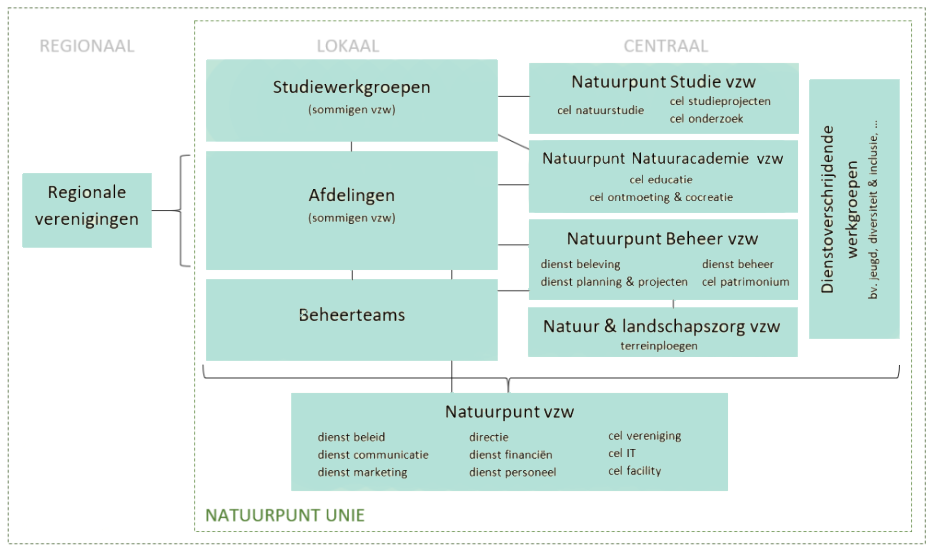

Organisatie Natuurpunt (click to enlarge)

### Structuur

Natuurpunt is gestructureerd op een manier die zowel **lokale betrokkenheid** als **nationale coördinatie** mogelijk maakt. De organisatie bestaat uit verschillende lagen:

- **Afdelingen:** Natuurpunt is georganiseerd in lokale afdelingen die elk verantwoordelijk zijn voor natuurbeheer en -bescherming in specifieke gebieden. Deze afdelingen spelen een cruciale rol in het lokale beheer van natuurgebieden, het organiseren van activiteiten en het betrekken van vrijwilligers en leden. Ze fungeren als de eerste lijn van de organisatie en zorgen voor directe betrokkenheid bij natuurbehoud op lokaal niveau. Via regionale koepels is Natuurpunt regionaal verankerd.
- **Natuurpunt vzw:** Boven de regionale afdelingen staat de algemene vzw Natuurpunt, die verantwoordelijk is voor de coördinatie van beleid, educatie, communicatie, marketing en ondersteunende diensten. Deze organisatie zorgt ervoor dat de verschillende regionale afdelingen samenwerken en dat er een samenhangend beleid wordt gevoerd.

  De regionale afdelingen zijn vertenwoordigd in de overkoepelende vzw via de Algemene vergadering die de belangrijke beslissingen neemt en de strategische richting van de organisatie vaststelt. De Raad van Bestuur, gekozen door de Algemene Vergadering, houdt toezicht op de uitvoering van het beleid en de dagelijkse werking van de organisatie.

  De dagelijkse werking van Natuurpunt wordt geleid door een directeur en een professioneel team van medewerkers die verantwoordelijk zijn voor het uitvoeren van projecten, het beheren van natuurgebieden, het coördineren van vrijwilligers en het ontwikkelen van educatieve programma’s.
- **Leden en Vrijwilligers:** Een belangrijk kenmerk van Natuurpunt is de actieve rol van leden en vrijwilligers. Vrijwilligers dragen bij aan het beheer van natuurgebieden, het organiseren van educatieve activiteiten, en het bevorderen van de bewustwording van natuur- en milieuproblemen. Leden ondersteunen de organisatie financieel en nemen deel aan evenementen en activiteiten.

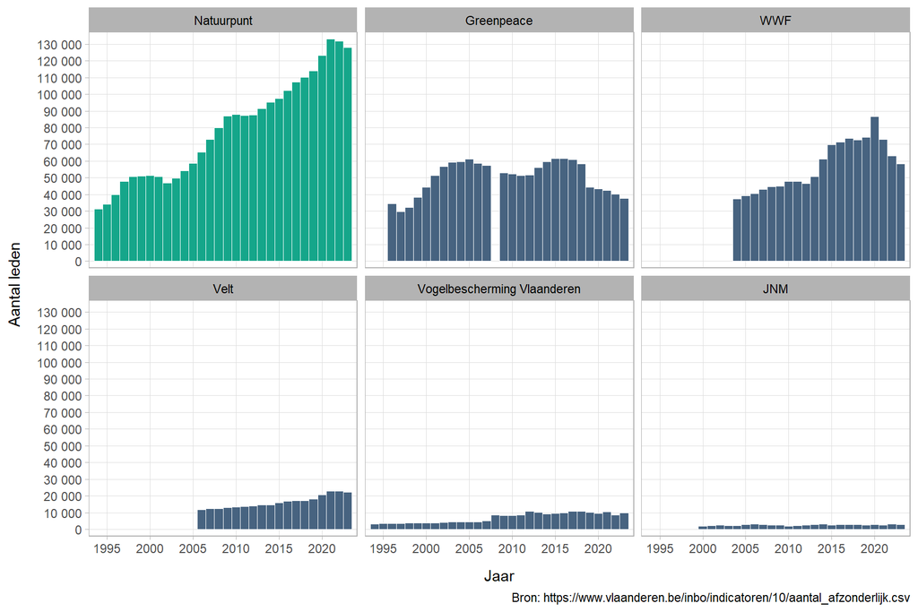

Figuur 1: Aantal leden milieuverenigingen

Tekst in opbouw